# TD1

# Informations

- Un seul projet tout le long du semestre
- Presentation de projet lors de la derniere seance
- Etude complete d’un jeu de donnée / nouvelle methode

#### Objectif TD : Manipuler dataframe

# Exercice 1

**read.csv2** = Fichier séparé par un point virgule avec une virgule pour séparateur décimal. Pas de header par défaut.

**read.delim** Fichier séparé par une tabulation avec un point pour séparateur décimal.

**read.delim2** Fichier séparé par une tabulation avec une virgule pour séparateur décimal.

Arguments :

**sep** Spécifie le séparateur

**header** Spécifie si la première ligne est une ligne d’en-tête

**row.names = 1** si la première colonne est une colonne nommant les individus (chaque ligne à un numero)

```r
iris1 <- read.table(sep='.',header = TRUE, "donnees/iris1.data")
```

```
Error in scan(file = file, what = what, sep = sep, quote = quote, dec = dec,  :
  line 2 did not have 5 elements
```

```r
check(iris2)
```

```
[1] "Chargement OK"
```

|  | Sepal.Length | Sepal.Width | Petal.Length | Petal.Width | Species |
| --- | --- | --- | --- | --- | --- |
| 1 | 5.1 | 3.5 | 1.4 | 0.2 | setosa |
| 2 | 4.9 | 3.0 | 1.4 | 0.2 | setosa |
| 3 | 4.7 | 3.2 | 1.3 | 0.2 | setosa |
| 4 | 4.6 | 3.1 | 1.5 | 0.2 | setosa |
| 5 | 5.0 | 3.6 | 1.4 | 0.2 | setosa |
| 6 | 5.4 | 3.9 | 1.7 | 0.4 | setosa |

```r
summary(iris1)
```

[output not shown]

# Exercice 2

**factor** : Correspond à une variable qualitative

**character** : Correspond à une variable qualitative mais stocké dans un vecteur plutôt qu’un facteur

**numeric** : Correspond à une variable quantitative continue

**integer** : Correspond à une variable quantitative discrète (les entiers naturels)

**logical** : Correspond à une variable binaire

```r
class(iris[,5])
```

```
[1] "factor"
```

```r
class(read.table(text='TRUE')[,1])
```

```
[1] "logical"
```

```r
class(read.table(text='F')[,1])
```

```
[1] "logical"
```

```r
class(read.table(text='A')[,1])
```

```
[1] "factor"
```

```r
class(read.table(text='3.14')[,1])
```

```
[1] "numeric"
```

```r
class(read.table(text='2')[,1])
```

```
[1] "integer"
```

```r
sapply(iris1, class)
```

```
Sepal.Length  Sepal.Width Petal.Length
   "numeric"    "numeric"    "numeric"
 Petal.Width      Species
   "numeric"     "factor"
```

Si la classe n’est pas correctement inférée par R, on peut les spécifier explicitement lors du chargement du jeu de données avec **l’argument colClasses**. Si cela n’est pas possible, il faut changer le type après chargement avec les fonctions :

- as.numeric
- as.logical
- as.integer
- as.factor
- as.ordered

[output not shown]

# Exercice 3

Parfois il est nécessaire de changer les modalités d’un facteur ou de changer leur ordre dans le cas d’un facteur ordonné. On pourra utiliser pour ce faire la commande factor :

- `donnees$champ1 <- factor(donnees$champ1, levels=modalites1)`
- `donnees$champ2 <- factor(donnees$champ2, levels=modalites2, ordered=T)`

```r
data <- read.csv("donnees/sy02-p2016.csv")
head(data)
```

|  | nom | specialite | niveau | statut | dernier.diplome.obtenu | note.median | correcteur.median | note.final | correcteur.final | note.totale | resultat |
| --- | --- | --- | --- | --- | --- | --- | --- | --- | --- | --- | --- |
| 1 | Etu1 | GI | 4 | UTC | BAC | 6.5 | Cor6 | 5.0 | Cor4 | 5.6 | F |
| 2 | Etu2 | GB | 2 | UTC | DUT | 6.5 | Cor6 | 13.0 | Cor4 | 10.4 | E |
| 3 | Etu3 | GSU | 4 | UTC | BAC | 14.0 | Cor2 | 17.0 | Cor3 | 15.8 | B |
| 4 | Etu4 | GSM | 2 | UTC | BAC | 13.0 | Cor2 | 13.5 | Cor3 | 13.3 | C |
| 5 | Etu5 | GI | 4 | UTC | DUT | 7.5 | Cor2 | 11.5 | Cor3 | 9.9 | Fx |
| 6 | Etu6 | GM | 4 | UTC | DUT | 8.5 | Cor4 | 10.5 | Cor5 | 9.7 | Fx |

```r
sapply(data, class)
```

```
                   nom             specialite                 niveau
              "factor"               "factor"              "integer"
                statut dernier.diplome.obtenu            note.median
              "factor"               "factor"              "numeric"
     correcteur.median             note.final       correcteur.final
              "factor"              "numeric"               "factor"
           note.totale               resultat
             "numeric"               "factor"
```

```r
data$niveau <- factor(data$niveau, levels = c("1","2","3","4","5","6"), ordered = T)
data$correcteur.median <- factor(data$correcteur.median, levels = unique(data$correcteur.median))
data$correcteur.final <- factor(data$correcteur.final, levels = unique(data$correcteur.final))
data$resultat <- factor(data$niveau, levels = c("A","B","C","D","E","Fx","F"), ordered = T)
sapply(data, class)
```

```
$nom
[1] "factor"

$specialite
[1] "factor"

$niveau
[1] "ordered" "factor"

$statut
[1] "factor"

$dernier.diplome.obtenu
[1] "factor"

$note.median
[1] "numeric"

$correcteur.median
[1] "factor"

$note.final
[1] "numeric"

$correcteur.final
[1] "factor"

$note.totale
[1] "numeric"

$resultat
[1] "ordered" "factor"
```

# Exercice 4

**NA** valeur non disponible (not available). **Inf** valeur infinie **NaN** Valeur non définie

# Exercice 5

|  | id | pluralty | outcome | date | gestation | sex | wt | parity | race | age | ed | ht | wt.1 | drace | dage | ded | dht | dwt | marital | inc | smoke | time | number |
| --- | --- | --- | --- | --- | --- | --- | --- | --- | --- | --- | --- | --- | --- | --- | --- | --- | --- | --- | --- | --- | --- | --- | --- |
| 1 | 15 | 5 | 1 | 1411 | 284 | 1 | 120 | 1 | 8 | 27 | 5 | 62 | 100 | 8 | 31 | 5 | 65 | 110 | 1 | 1 | 0 | 0 | 0 |
| 2 | 20 | 5 | 1 | 1499 | 282 | 1 | 113 | 2 | 0 | 33 | 5 | 64 | 135 | 0 | 38 | 5 | 70 | 148 | 1 | 4 | 0 | 0 | 0 |
| 3 | 58 | 5 | 1 | 1576 | 279 | 1 | 128 | 1 | 0 | 28 | 2 | 64 | 115 | 5 | 32 | 1 | 99 | 999 | 1 | 2 | 1 | 1 | 1 |
| 4 | 61 | 5 | 1 | 1504 | 999 | 1 | 123 | 2 | 0 | 36 | 5 | 69 | 190 | 3 | 43 | 4 | 68 | 197 | 1 | 8 | 3 | 5 | 5 |
| 5 | 72 | 5 | 1 | 1425 | 282 | 1 | 108 | 1 | 0 | 23 | 5 | 67 | 125 | 0 | 24 | 5 | 99 | 999 | 1 | 1 | 1 | 1 | 5 |
| 6 | 100 | 5 | 1 | 1673 | 286 | 1 | 136 | 4 | 0 | 25 | 2 | 62 | 93 | 3 | 28 | 2 | 64 | 130 | 1 | 4 | 2 | 2 | 2 |

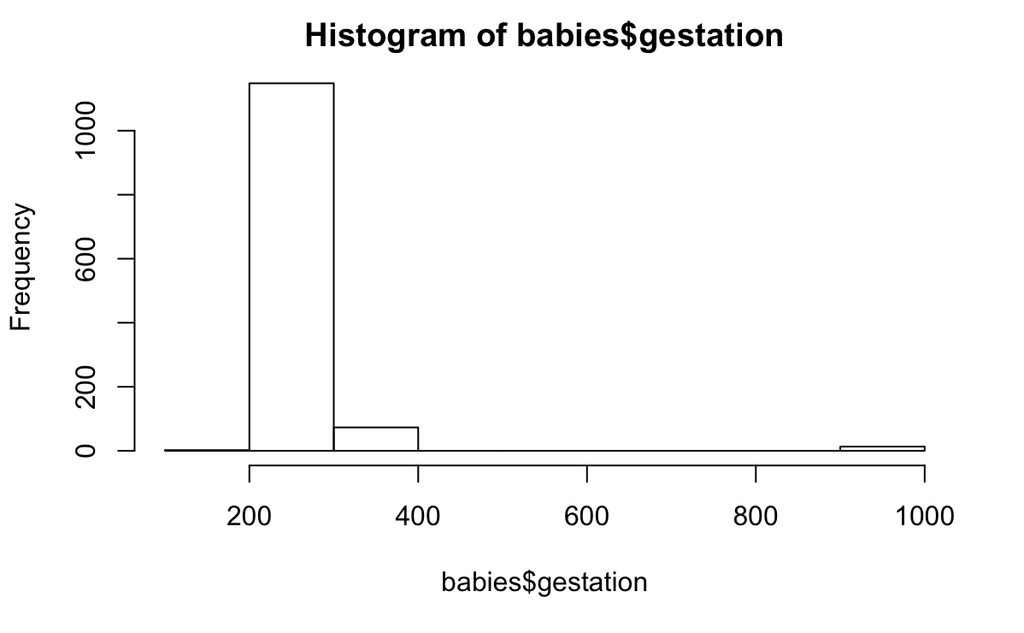

```r
babies <- data[,c(7,5,8,10,12,13,21,11)]
names(babies) <- c("bwt", "gestation", "parity", "age", "height", "weight", "smoke", "education")
hist(babies$gestation)
```

```r
babies$bwt[babies$bwt == 999] <- NA
babies$gestation[babies$gestation == 999] <- NA
babies$age[babies$age == 99] <- NA
babies$height[babies$height == 99] <- NA
babies$weight[babies$weight == 999] <- NA
babies$smoke[babies$smoke == 9] <- NA
babies$education[babies$education == 9] <- NA
sapply(babies, class)
```

```
      bwt gestation    parity       age    height    weight     smoke education
"integer" "integer" "integer" "integer" "integer" "integer" "integer" "integer"
```

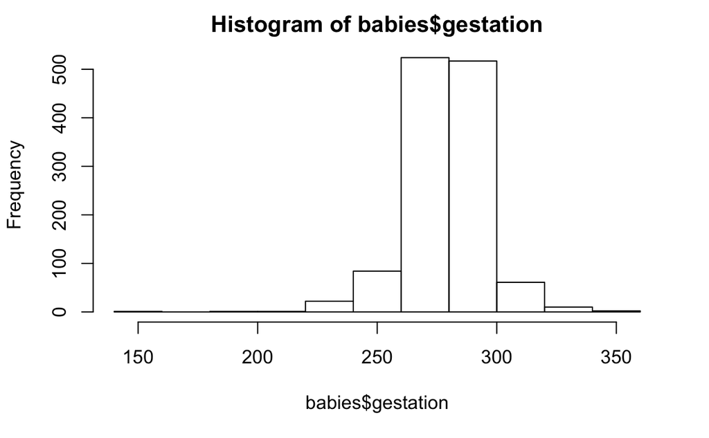

```r
babies$education <- factor(babies$education, ordered = T, levels = unique(babies$education))
babies$smoke[babies$smoke != 1] <- "NonSmoking"
babies$smoke[babies$smoke == 1] <- "Smoking"
hist(babies$gestation)
```